# Моделирование процесса восстановления золота из золотосодержащей руды

## Вывод

Вид распределения на тренировочной выборке практически не отличается от распределения на тестовой выборке,поэтому мы можем говорить о том,что оценка модели будет корректной.

### Исследование суммарной концентрации всех веществ на разных стадиях: в сырье, в черновом и финальном концентратах

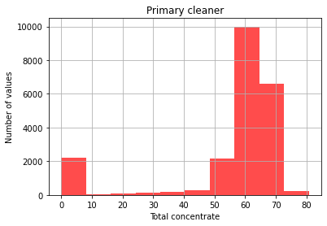

```python
# сначала для сырья
total_primary = full_data['primary_cleaner.output.concentrate_pb'] + full_data['primary_cleaner.output.concentrate_ag'] + full_data['primary_cleaner.output.concentrate_sol'] + full_data['primary_cleaner.output.concentrate_au']
total_primary.hist(color='r',alpha=0.7)
plt.xlabel('Total concentrate')
plt.ylabel('Number of values')
plt.title('Primary cleaner')
plt.show();
```

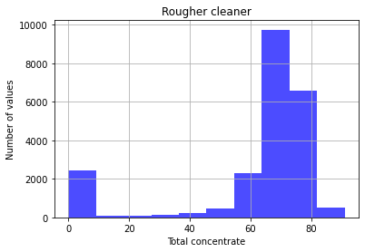

```python
# теперь для грубой очистки
total_rougher = full_data['rougher.output.concentrate_pb'] + full_data['rougher.output.concentrate_ag'] + full_data['rougher.output.concentrate_sol'] + full_data['rougher.output.concentrate_au']
total_rougher.hist(color='b',alpha=0.7)
plt.xlabel('Total concentrate')
plt.ylabel('Number of values')
plt.title('Rougher cleaner')
plt.show();
```

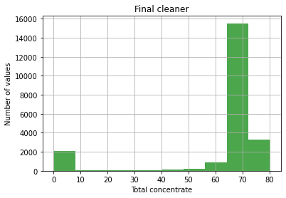

```python
total_final = full_data['final.output.concentrate_pb'] + full_data['final.output.concentrate_ag'] + full_data['final.output.concentrate_sol'] + full_data['final.output.concentrate_au']
total_final.hist(color='g',alpha=0.7)
plt.xlabel('Total concentrate')
plt.ylabel('Number of values')
plt.title('Final cleaner')
plt.show();
```

```python
# удалим выбросы из обеих выборок
full_data = full_data[(total_final >= 40) & (total_rougher >= 40) & (total_primary >= 40)]
```

```python
full_data.dropna(subset=['final.output.recovery','rougher.output.recovery'],inplace=True)
```

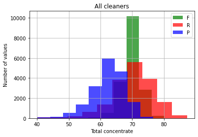

```python
total_final = full_data['final.output.concentrate_pb'] + full_data['final.output.concentrate_ag'] + full_data['final.output.concentrate_sol'] + full_data['final.output.concentrate_au']
total_rougher = full_data['rougher.output.concentrate_pb'] + full_data['rougher.output.concentrate_ag'] + full_data['rougher.output.concentrate_sol'] + full_data['rougher.output.concentrate_au']
total_primary = full_data['primary_cleaner.output.concentrate_pb'] + full_data['primary_cleaner.output.concentrate_ag'] + full_data['primary_cleaner.output.concentrate_sol'] + full_data['primary_cleaner.output.concentrate_au']

total_final.hist(color='g',alpha=0.7)
total_rougher.hist(color='r',alpha=0.7)
total_primary.hist(color='b',alpha=0.7)

plt.legend('FRP')
plt.xlabel('Total concentrate')
plt.ylabel('Number of values')
plt.title('All cleaners');
```

### Почистим тестовую и тренировочную выборки от выбросов

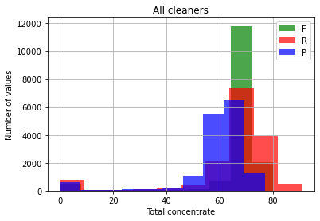

```python
train_primary = train_data['primary_cleaner.output.concentrate_pb'] + train_data['primary_cleaner.output.concentrate_ag'] + train_data['primary_cleaner.output.concentrate_sol'] + train_data['primary_cleaner.output.concentrate_au']
train_rougher = train_data['rougher.output.concentrate_pb'] + train_data['rougher.output.concentrate_ag'] + train_data['rougher.output.concentrate_sol'] + train_data['rougher.output.concentrate_au']
train_final = train_data['final.output.concentrate_pb'] + train_data['final.output.concentrate_ag'] + train_data['final.output.concentrate_sol'] + train_data['final.output.concentrate_au']

train_final.hist(color='g',alpha=0.7)
train_rougher.hist(color='r',alpha=0.7)
train_primary.hist(color='b',alpha=0.7)

plt.legend('FRP')
plt.xlabel('Total concentrate')
plt.ylabel('Number of values')
plt.title('All cleaners')
plt.show();
```

```python
train_data = train_data[(train_final >= 40) & (train_rougher >= 40) & (train_primary >= 40)]
```

```python
test_data = test_data[test_data['date'].isin(full_data['date'])]
```

```python
train_data.shape,test_data.shape
```

```
((13641, 87), (4918, 53))
```

## Вывод

Посмотрев на графики распределения данных концентрации на полной выборке мы наблюдаем выбросы,которые сильно могут повлиять на конечный результат исследования,поэтому мы их удаляем и соответственно можем сделать то же самое и на тренировочной и на тестовой выборке,потому что эти данные по сути брались из нашей полной выборки.